# Zadanie domowe 2

Anna Urbala

23 października 2019

## Wykres przed:

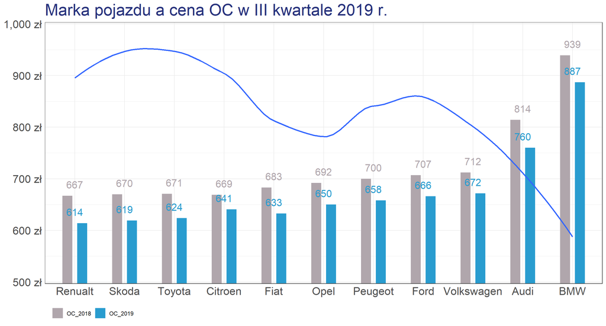

## Wczytanie danych

Dane przekopiowałam od kolegi, ale podmieniłam szkody na procenty, gdyż nie wiedziałam, co dokładnie przedstawia obecna wartość.

```r
data <- read.csv('dane.csv')
```

## Nowy pomysł

W tym celu przede wszystkim podzielę powyższy wykres na dwa. Dodatkowo postaram się poprawić nieco etykiety

### Porównanie kwot OC w latach 2018-2019

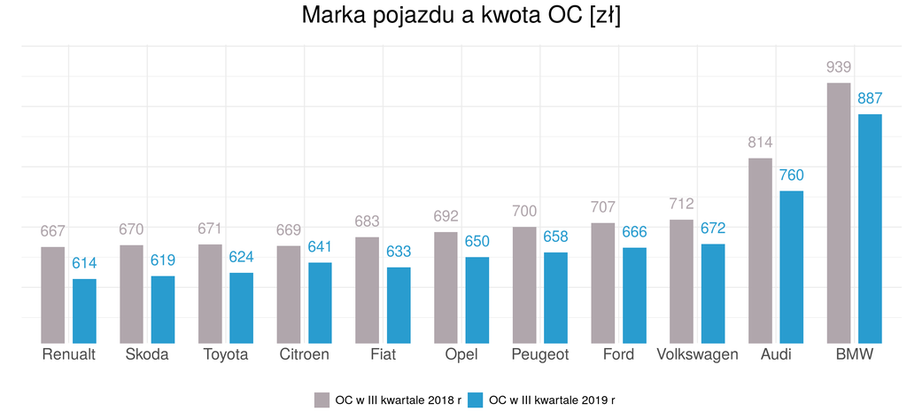

```r
ggplot(
    data,
    aes(x = reorder(marka, OC), weight = OC, fill = rok)) +
  theme_minimal() +
  ggtitle("Marka pojazdu a kwota OC [zł]") +
  scale_fill_manual(
    values = c('#B0A6AC', '#299CCF'),
    labels = c("OC w III kwartale 2018 r", "OC w III kwartale 2019 r")) +
  geom_bar(
    position = position_dodge(width = 0.8),
    width = 0.6) +
  coord_cartesian(
    ylim = c(530, 980)) +
  geom_text(
    aes(label = OC, x = marka, y = OC),
    vjust=-1,
    color=rep(c('#299CCF', '#B0A6AC'), times=11),
    size=5.5,
    position = position_dodge(width = 0.8))+
  theme(
    axis.text = element_text(size = 16),
    plot.title = element_text(
      size = 24,
      hjust = 0.5,
      margin = margin(t = 0, r = 0, l = 0, b = 20)),
    legend.position = "bottom",
    legend.box = "horizontal",
    legend.justification = "center",
    legend.text = element_text(size=12),
    axis.text.y = element_blank()) +
  labs(x = "", y = "", fill = "")
```

Powyższy wykres ma poprawione etykiety słupków i legendę. Dodatkowo tytuł i legenda zostały wyśrodkowane. Linia szkód została usunięta, więc nie zaburza obrazu. Poprawiłam też nieco szerokość słupków, żeby całość wyglądała bardziej estetycznie.

### Kwota OC a procent kierowców deklarujących szkody

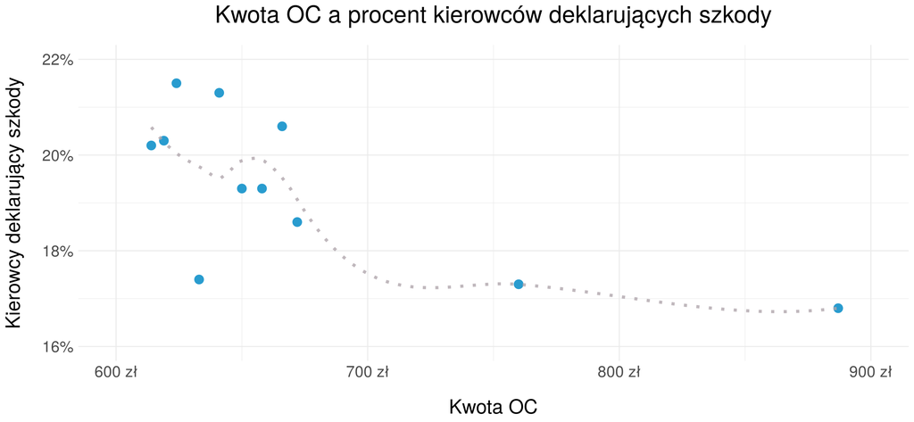

```r
data <- data %>%
  filter(rok == "OC_2019")

ggplot(
    data,
    aes(x = OC, y = szkody)) +
  theme_minimal() +
  ggtitle("Kwota OC a procent kierowców deklarujących szkody") +
  labs(x = "Kwota OC", y = "Kierowcy deklarujący szkody") +
  geom_point(size = 4, color = "#299CCF") +
  coord_cartesian(
    ylim = c(16,22),
    xlim = c(600, 900)) +
  theme(
    axis.text = element_text(size = 16),
    axis.title.y = element_text(
      size = 20,
      margin = margin(t = 0, r = 20, b = 0, l = 0)),
    axis.title.x = element_text(
      size = 20,
      margin = margin(t = 20, r = 0, b = 0, l = 0)),
    plot.title = element_text(
      size = 24,
      hjust = 0.5,
      margin = margin(t = 0, r = 0, l = 0, b = 20))) +
  scale_y_continuous(
    label = scales::dollar_format(prefix = "", suffix = "%")) +
  scale_x_continuous(
    label = scales::dollar_format(prefix = "", suffix = " zł")) +
  geom_line(
    stat="smooth",
    method = "loess",
    formula = y ~ x,
    linetype ="dotted",
    size = 1.5,
    alpha = 0.8,
    color = "#B0A6AC")
```

Drugi wykres zachowuje kolorystykę poprzedniego. Marki samochodów zostały naniesione jako punkty, ale dodatkowo jest linia trendu narysowana metodą LOESS, więc można zauważyć pewne zachowanie danych. Rozdzielenie wykresów na dwa zdecydowanie poprawiło ich czytelność i w obecnej formie wiadomo, czym jest linia dotycząca szkód.